# 2) Clustering and cell type annotation

2025-10-23

# Setup

```r
#Load helper functions
source("/people/nrq364/NeuSiC/scRNA_helper_new.R")

library(magrittr)
library(dplyr)
library(conos)
library(pagoda2)
library(qs)
library(ggplot2)
library(ggrastr)
library(openxlsx)
```

# 1. Read in data

Read in filtered list of cms generated in notebook 1) Pre-processing and QC filtering.

```r
cms <- qread("cms_filtered.qs", nthreads = 10)
```

# 2. Embed cells in UMAP graph using conos

Create a vector with sample names.

```r
names=c("control_1_",
           "control_2_",
           "control_4_",
           "control_5_",
           "control_6_",
           "control_7_",
          "treated_1_",
           "treated_2_",
           "treated_3_",
         "treated_4_",
           "treated_6_",
           "treated_7_")
```

Use a helper function (defined in the script “scRNA_helper_new.R”) to embed cells in a UMAP graph and perform first clustering. This helper function performs pagoda2 preprocessing of each count matrix, then creates a conos object and integrates the samples into one UMAP graph. Alignment strength can be adjusted to force stronger integration of samples.

```r
con <- quickConos(cms,
                  names,
                  n.cores.p2=10,
                  n.cores.con=20, get.tsne = F, alignment.strength=0)

con <- con$con
```

Investigate how cells cluster on the UMAP. Are there any batches visible (clustering by sample, by condition)? If yes, alignment.strength parameter can be increased.

Plot UMAP coloured by sample.

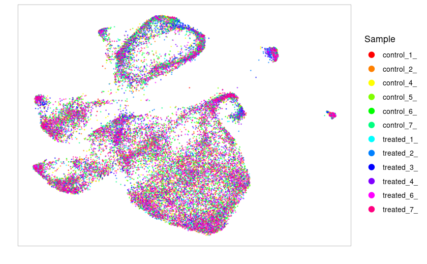

```r
data <- con$plotGraph(groups=con$getDatasetPerCell())
data <- data$data
plot1 <- ggplot(data, aes(x = x, y =y, color= Group))+ geom_point(size=0.2, alpha=0.5)+ theme_light()+ theme(panel.grid.major = element_blank(), panel.grid.minor = element_blank())+ xlab("")+ylab("") + theme(axis.ticks = element_blank(), axis.text =element_blank())+labs(color = "Sample") +guides(color = guide_legend(override.aes = list(size=3, alpha=1)))+scale_color_manual(values=rainbow(12))
plot1
```

Plot UMAP coloured by cluster.

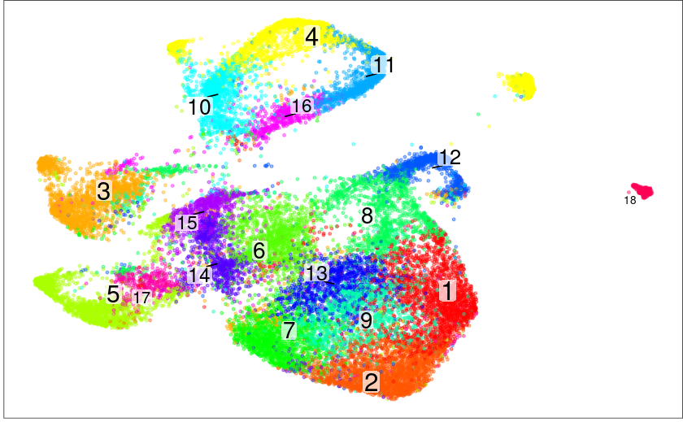

```r
con$plotGraph() +  theme(panel.grid.major = element_blank(), panel.grid.minor = element_blank())+ xlab("")+ylab("") + theme(axis.ticks = element_blank(), axis.text =element_blank())
```

Plot UMAP coloured by condition Get condition factor to colour UMAP by condition.

```r
condition <- con$getDatasetPerCell() %>% substr(1, 7) %>%
  setNames(names(con$getDatasetPerCell()))
condition <- as.factor(condition)
#head(condition)
```

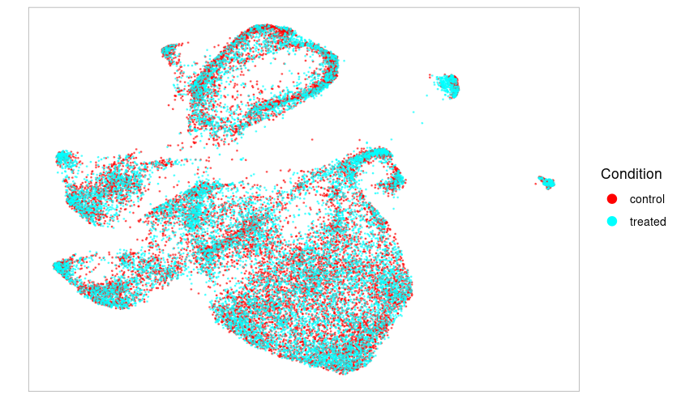

```r
data <- con$plotGraph(groups=condition)
data <- data$data
plot3<-ggplot(data, aes(x = x, y =y, color= Group))+ geom_point(size=0.2, alpha=0.5)+ theme_light()+ theme(panel.grid.major = element_blank(), panel.grid.minor = element_blank())+ xlab("") + ylab("") + theme(axis.ticks = element_blank(), axis.text =element_blank())+labs(color = "Condition") +guides(color = guide_legend(override.aes = list(size=3, alpha=1))) +scale_color_manual(values=rainbow(2))
plot3
```

Save conos object if satisfied with sample integration. Otherwise adjust alingment strength parameter.

```r
qsave(con, "con.qs")
```

# 3. Refine clustering

Rerun the leiden clustering algorithm to refine the clusters. Not performed here, just the code is shown.

```r
con$findCommunities(method = leiden.community, resolution = 4, min.group.size = 50)
```

```r
con$plotGraph(groups = con$clusters$leiden$groups %>% factor, title="")
table(con$clusters$leiden$groups %>% factor)
```

Get the clustering factor from conos object.

```r
leiden_number_of_clusters <- con$clusters$leiden$groups %>% factor
```

Save conos object with final clustering and also the clustering vector.

```r
qsave(leiden_number_of_clusters, "leiden_number_of_clusters.qs")
qsave(con, "con.qs")
```

# 4. Cluster marker genes

Get upregulated genes per cluster (=marker genes), use only control cells, because treatment can alter marker gene expression. Use the leiden factor saved above and extract only the ctrl cells.

```r
anno <- con$clusters$leiden$groups %>% factor
head(anno)
```

```r
anno_ctrl <- anno[grep("control", names(anno))]
length(anno_ctrl)
```

Then, get marker genes per cluster from control cells.

```r
de_conos <- con$getDifferentialGenes(groups=anno_ctrl, append.auc = T, upregulated.only = T)
```

In addition to common parameters (p value, p.adj, Z score and M (mean expression)), getDifferentialGenes estimates specificity, precision and expression fraction (sum expression of the gene within the cluster divided by the total expression of this gene). If the append.auc flag is set, it can estimate ROC AUC, but it can take some time. In the context of differential gene expression (DEG) analysis, a z-score indicates how many standard deviations a specific gene’s expression in treated samples of a particular cell type deviates from the mean expression of that gene across both control and treated samples within the same cluster.

```
Positive z-score: The gene's expression in treated samples is above the mean.
Negative z-score: The gene's expression in treated samples is below the mean.
```

```r
head(de_conos$`1`)
```

Export top 30 genes for users to look at. Ordering by AUC instead of P value gives more genes that are highly expressed in the respective cluster.

```r
lapply(de_conos, function(x) {x %>% arrange(desc(AUC)) %>% head()})
```

Transform the list of marker genes into one big table by adding the column “Clusters”. Order by AUC and save csv file with top 30 genes.

```r
library(data.table)
de_conos <- lapply(de_conos, function(x) {x %>% arrange(desc(AUC)) %>% head(30)})
write.xlsx(de_table, file = "top30_marker_byAUC.csv")
```

## 4.1 Plot marker genes on UMAP

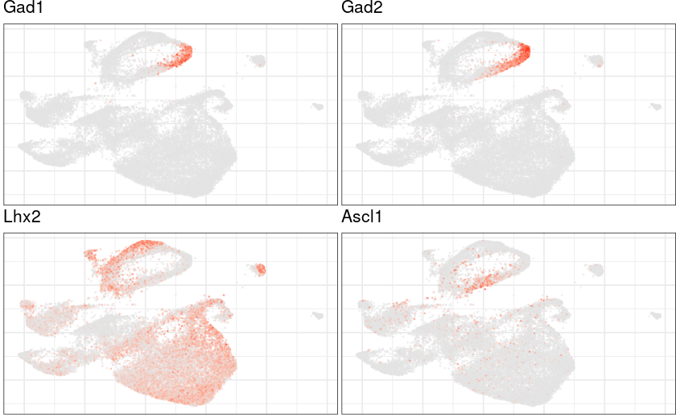

```r
#plot several genes
genes <- c("Gad1", "Gad2", "Lhx2", "Ascl1")
plots <- lapply(genes, function(gene) {
  con$plotGraph(gene = gene, title = gene, size = 0.2)
})
cowplot::plot_grid(plotlist = plots)
```

# 5.1 Create pagoda for user annotation or data exploration by user

Merge the list of count matrices.

```r
cm <- conos:::mergeCountMatrices(cms,F)
```

```r
checkDims(cm, con)
```

Perform pagoda2 processing on merged matrices.

```r
p2 <- basicP2proc(cm, n.cores = 20, n.odgenes = 3e3, nPcs = 50, k = 30, perplexity = 50, log.scale = TRUE, trim = 10, keep.genes = NULL, min.cells.per.gene = 3, min.transcripts.per.cell = 200, get.largevis = F, get.tsne = F, make.geneknn = F)
```

```r
p2 <- extendedP2proc(p2, organism="mm")
go.env2 <- p2$go.env
p2 <- p2$p2
```

Add all the cell metadata relevant for you, e.g. depth, mito fraction, batches in which the samples were processed, sequencing batch.

```r
mit_frac <- mitoFraction(con, "mouse")
mit_frac <- as.factor(round(mit_frac, digits=3))
depth <- getConosDepth(con)
sample <- con$getDatasetPerCell()
seq_batch <- sample
levels(seq_batch) <- c(1,2,3,2,4,5,4,5)
batch2 <- sample
levels(batch2) <- c(1,2,2,2,3,4,3,4)

metadata.listfactors <- list(sample = sample,
                             depth = depth,
                             seq_batch = seq_batch,
                             batch2 = batch2,
                             mit_frac = mit_frac,
                             cluster = leiden)
metadata.forweb <- factorListToMetadata(metadata.listfactors)
```

Create the web object.

```r
p2.web <- webP2proc(p2, additionalMetadata = metadata.forweb, title = '[user_name] ', go.env = go.env2, make.go.sets = F)

#Add UMAP embedding
p2.web <- addEmbeddingP2Web(p2.web, con)

#Create .bin-file
p2.web$serializeToStaticFast('p2web_user_name.bin',verbose=T)
```

Preview the web app.

```r
show.app(app=p2.web, name='app')
```

To share files via webserver 1. copy file to `/pub_html/neusic` 2. make file readable for external users with `chmod 775` 3. access the file via URL: http://kkh.bric.ku.dk/p2auto/index.html?fileURL=http://kkh.bric.ku.dk/neusic/p2web_username.bin

# 5.2 Automated annotation

Need to be tested and verified. Options:

- SingleR
- SignacX
- Cellranger build-in annotation tool.

# 6. Useful functions for refining and annotating clusters

To refine the clustering you can subcluster specific clusters. Subcluster cluster 18:

```r
anno <- findSubcommunities(con, "18", groups=anno, resolution=1)
anno %<>% as.factor()
levels(anno)
```

Plot new cluster on UMAP:

```r
con$plotGraph(groups = anno, title="", size=0.2)
```

Pot only cells of a specific cluster on UMAP:

```r
con$plotGraph(groups=anno, subgroups="18_3", size=0.2)
```

Use helper functions from scRNA_helper.R to rename or collapse clusters. Rename cluster “18_3” to “immune_cells”.

```r
anno %<>% renameAnnotation("18_3", "immune_cells")
```

Collapse all clusters with “18” in their name.

```r
anno %<>% collapseAnnotation("18")
```

# 7. Final plots

Final UMAP coloured by cluster Define costume colours of clusters.

```r
colours <- c( "#FF0000" ,"#FF6000", "#FFBF00", "#DFFF00" ,"#00FFFF" , "#20FF00", "#00FF40", "#DF00FF","#80FF00","#009FFF", "#0040FF","#FF0060" , "#8000FF", "#00FF9F", "#FF00BF","#2000FF" ) %>% setNames(c("Cajal_Retzius_cells", "CGE_progenitors","Cortical_hem"  ,  "Dorsal_IPC" ,  "Immature_GABAergic_N","Highly_prolif_RG_S" , "Immature_PN",    "Immature_PN_Tbr1","MGE_progenitors","Microglia",
 "Dorsal_RG" , "Anteriomedial_RG", "Lateral_RG", "PIC_immature_PN", "Roof_plate","Highly_prolif_RG_G2M"))
```

## 7.1 UMAP without cell type annotation, so user can add cell type names.

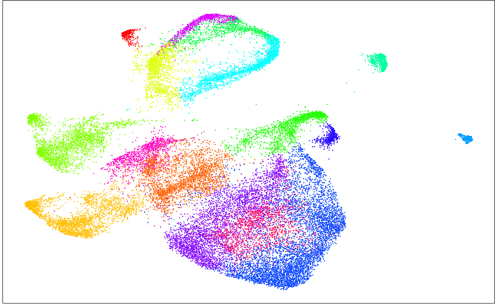

```r
con$plotGraph(groups=anno, color.by="cluster",mark.groups=F, size=0.2) + theme(panel.grid.major = element_blank(), panel.grid.minor = element_blank())+ scale_colour_manual(values=colours)
```

## 7.2 UMAP with cell type names

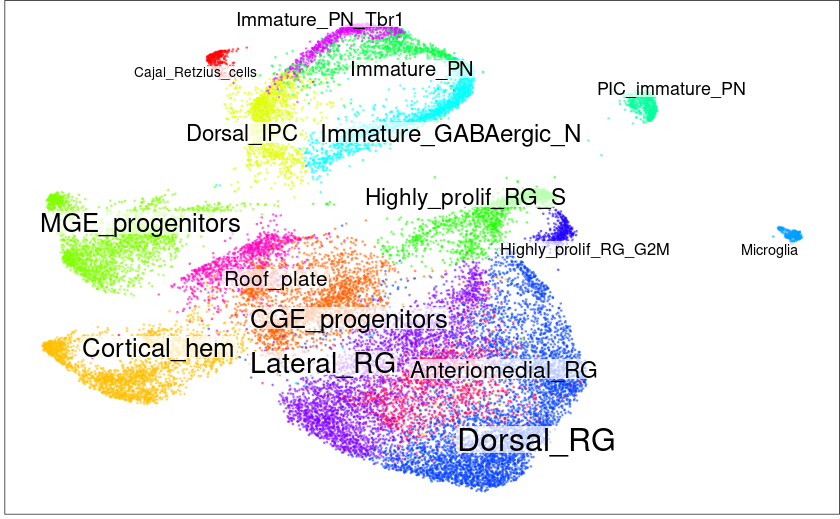

```r
con$plotGraph(groups=anno, color.by="cluster",mark.groups=T, size=0.2) + theme(panel.grid.major = element_blank(), panel.grid.minor = element_blank())+ scale_colour_manual(values=colours)
```

## 7.3 UMAP with cell type names in legend

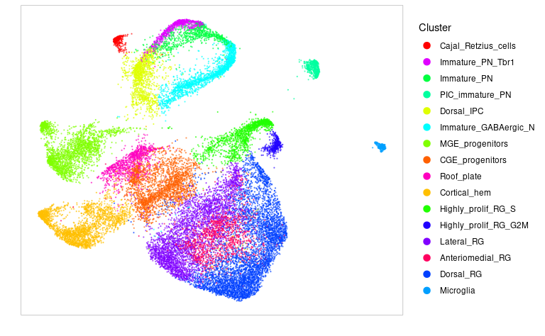

```r
data <- con$plotGraph()
data <- data$data
plot2 <- ggplot(data, aes(x = x, y =y, color=Group))+ geom_point(size=0.2, alpha=0.5)+ theme_light()+ theme(panel.grid.major = element_blank(), panel.grid.minor = element_blank())+ xlab("")+ylab("") + theme(axis.ticks = element_blank(), axis.text =element_blank())+labs(color = "Cluster") +guides(color = guide_legend(override.aes = list(size=3, alpha=1)))+scale_color_manual(values=colours)
plot2
```

## 7.4 UMAP coloured by condition

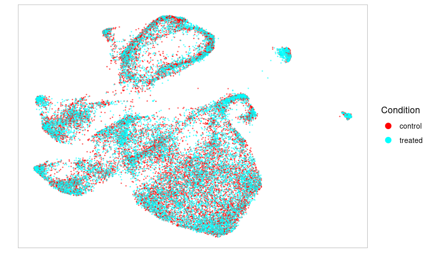

```r
data <- con$plotGraph(groups=condition)
data <- data$data
plot3<-ggplot(data, aes(x = x, y =y, color= Group))+ geom_point(size=0.2, alpha=0.5)+ theme_light()+ theme(panel.grid.major = element_blank(), panel.grid.minor = element_blank())+ xlab("") + ylab("") + theme(axis.ticks = element_blank(), axis.text =element_blank())+labs(color = "Condition") +guides(color = guide_legend(override.aes = list(size=3, alpha=1))) + scale_color_manual(values=rainbow(2))
plot3
```

## 7.5 Dotplot of marker genes

Join the list of count matrices into one count matrix.

```r
cm <- con$getJointCountMatrix(raw=F)
```

Create vector of relevant marker genes.

```r
markers <- c("Trp73", "Reln", 'Eomes','Tbr1','Slc17a6' ,'Dcx','Thsd7b','Neurod1' ,'Neurog2','Btg2','Gad2','Dlx1','Nkx2-1','Shh','Nr2f2','Ptprz1','Wnt3','Rspo3', 'Rspo2', 'Bmp6',"Pax6",'Mcm4','Sox2','Nes','Rplp1','Meis2','Mpped1','Zic1','Zic4','Emx2', 'Creb5','Csf1r', "Spi1")
```

Order cell types in annotation factor in costume order.

```r
anno_order <- factor(anno, levels=c('Cajal_Retzius_cells', 'Immature_PN_Tbr1' , 'Immature_PN','PIC_immature_PN', 'Dorsal_IPC','Immature_GABAergic_N','MGE_progenitors','CGE_progenitors', 'Roof_plate', 'Cortical_hem','Highly_prolif_RG_S','Highly_prolif_RG_G2M','Lateral_RG', 'Anteriomedial_RG', 'Dorsal_RG', 'Microglia'))
```

Create dot plot of marker genes.

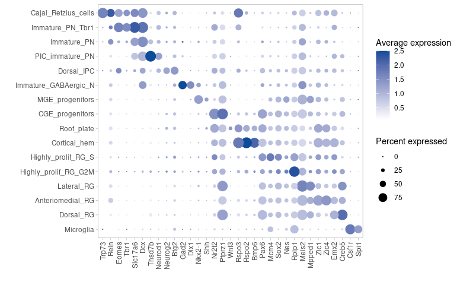

```r
sccore::dotPlot(markers, cm, cell.groups = anno_order, gene.order = T, xlab = "", ylab = "", cols=c("white","#0E4B99")) +theme_light()+ theme(axis.text.x=element_text(angle=90, hjust=1, vjust=0.5))+ theme(text = element_text(size = 11)) + theme(panel.grid.major = element_blank(), panel.grid.minor = element_blank())
```

## 7.6 Barplot of number of cells per cluster

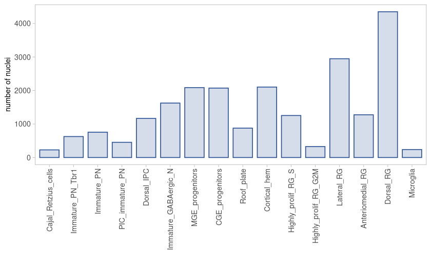

```r
anno_table <- as.data.frame(table(anno_order))
ggplot(anno_table, aes(anno_order, Freq)) + geom_bar(stat = "identity",fill="#2F5496", alpha=0.2, color="#2F5496", width=0.8) + xlab("") + ylab("number of nuclei") + theme_light()+ theme(axis.text.x=element_text(angle=90, hjust = 1, vjust = 0.5)) + theme(panel.grid.major = element_blank(), panel.grid.minor = element_blank()) +
  theme(axis.title.y = element_text(size = 9), axis.text.x =  element_text(size = 9),axis.text.y =  element_text(size = 9))
```

## 7.7 Stacked barplots of composition of samples per cluster

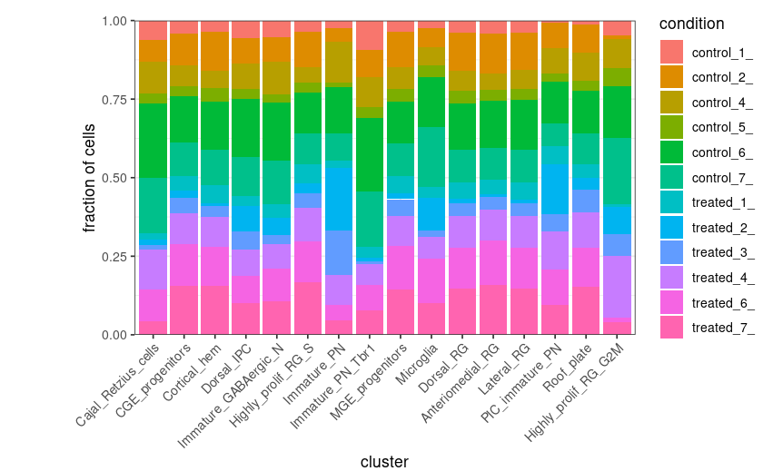

```r
plotClusterBarplots(con, groups = anno , show.entropy = F, show.size = F) + theme(axis.text.x = element_text(angle = 45, hjust = 1)) + scale_fill_discrete(name = "condition") +
  theme(plot.margin = margin(0.5,0,0,2, "cm"))
```

## 7.8 Stacked barplots of composition of conditions per cluster

Ge the condition factor or have a metadata table.

```r
condition <- con$getDatasetPerCell() %>% substr(1, 7) %>%
  setNames(names(con$getDatasetPerCell()))
condition <- as.factor(condition)
#head(condition)
```

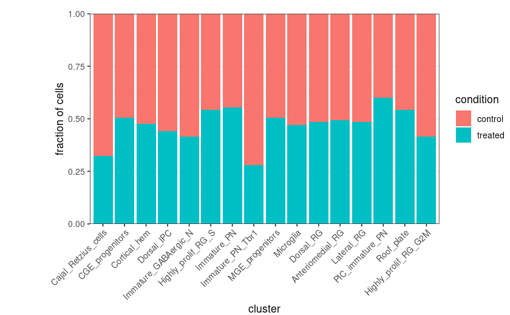

```r
plotClusterBarplots(con, groups = anno , show.entropy = F, show.size = F, sample.factor = condition) + theme(axis.text.x = element_text(angle = 45, hjust = 1)) + scale_fill_discrete(name = "condition") +
  theme(plot.margin = margin(0.5,0,0,2, "cm"))
```